# Cartogram Mapping and its Application to Cancer Data Visualisation

Stephanie Kobakian, Jessie Roberts and Dianne Cook

# Introduction

Maps have been adopted to present geospatial statistics for centuries. Maps connect data and statistics to the geographical representation of areas that are generally familiar to the audience. However, it is not enough for areas on maps to be recognisable, if information regarding the distribution of the statistic cannot be gleaned. In situations where the people are of interest, not the land they live on, it is reasonable to explore views that enhance the communication of the cancer statistics. Identifying and explaining spatial structures, patterns, and processes involves considering the individuals in communities and organising communities into representable units (Moore and Carpenter 1999). This has spurred innovations over the previous centuries to enhance the shapes and maps presented to effectively communicate cancer outcomes, and health outcomes more broadly. Cancer statistics directly represent and relate to the people living within individual geographical areas.

The visualisation methods used to present cancer statistics will depend on the intended message and users of the map. Transforming statistics to visualisations considers individual observations or observation points aggregated into communities and geographical units. Visualising diseases on maps is often the first step in exploratory spatial data analysis and effectively helps in the formulation of hypotheses (Jahan et al. 2018). Disease maps help to present geographic patterns that may have been overlooked in a table, obscuring the geospatially related statistics (Moore and Carpenter 1999). By providing a visual representation of cancer outcomes, geographic patterns of disease are able to be identified and effectively addressed.

# Disease mapping methods

## Current best practice map displays for cancer data

A choropleth map is used to display the spatial characteritics of a relationship, or variability, of measurements. As an alternative storage device to a table, it preserves locations for geographically ordered data, with usage dating back to the 1800s (Berry, Morrill, and Tobler, n.d.). A choropleth is constructed by drawing the geographic or political boundaries, and filling the shapes with colours to represent values of a measured variable (Tufte 1990). Early versions of choropleth maps used symbols or patterns instead of colour. Bell et al. (2006) discusses their use in visualising cancer data, and Walter (2001) gives an overview of the development of these maps for displaying disease data. Just as geographers are no longer the only creators of maps, Bell et al. (2006) suggests the audiences of spatial health data analysis have extended beyond researchers to the public, policymakers and the media. A choropleth map is a true map of the topology, constructed for visual inspection of spatial patterns across a familiar geographic form. Figure 1 shows a choropleth map where each state of the United States of America is coloured by the average annual rate of new cases of lung and bronchus cancer from years 2012 to 2016.

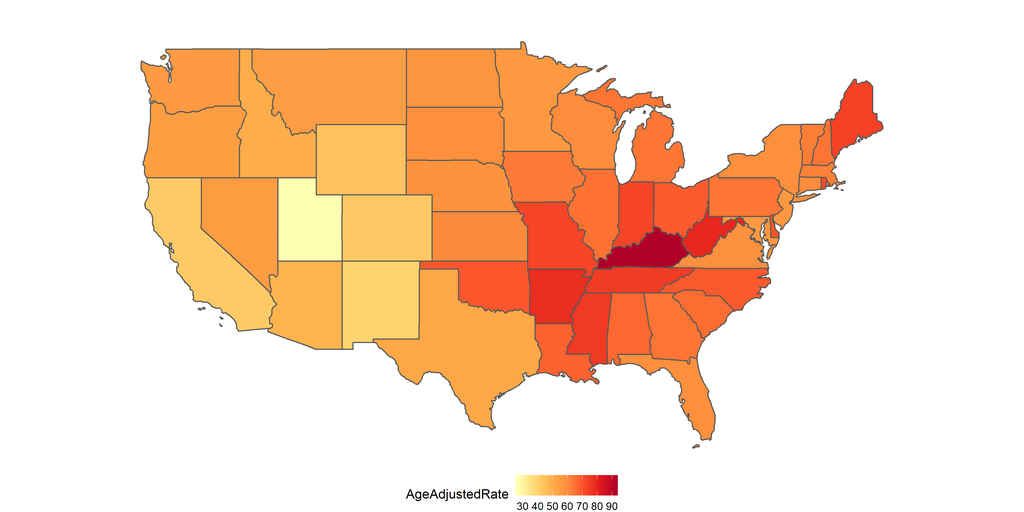

A choropleth map of the United States of America.

Utilising the familiar state boundaries can make a map intuitive to read (Brewster and Subramanian 2010), and allow viewers to visually infer the spatial relationships in the data, i.e. how cancer rate differs across the states. The familiarity of the geography is a worthy consideration when presenting results of spatial analysis. Just as geographers are no longer the only creators of maps, Bell et al. (2006) suggests the audiences of spatial health data analysis have extended beyond researchers to the public, policymakers and the media. While the areas are recognisable shapes, they are often politically driven boundaries with individual areas being of non-uniform size, containing different population densities and subject to change over time. The different population and geographical sizes of administrative areas can attract attention to the shades of the unpopulated but large areas (Tufte 1990). Choropleths can inhibit visual inference when presenting human related statistics as the display may draw attention from the ‘potentially more important results in the more populous communities’ (Exeter 2017).

Almost 100 years of cancer mapping in the United States and the United Kingdom has seen increased effectiveness in the presentation cancer statistics. Mortality rates are now often presented as relative rates of risk across the population, and age adjusted to correct for the the higher prevalence of cancers in older populations. Howe (1989) describes Stock’s development of the standardised mortality ratios through the 1930s. Table 1 presents summarises the measures presented in published cancer atlases, and provides a definition of each measure.

Table 1: Measures used to report cancer statistics

| Measure | Details |
| --- | --- |
| 1. IR (Incidence Ratio) | $(IR)_i=\frac{(Incidence\ Rate)_i}{Average\ Incidence\ Rate}$, |
|  | Cancer incidence rate in region $i$ over the average cancer incidence rate for the total region |
| 2. SIR (Standardised Incidence Ratio) | IR standardised by age structure in each region $i$ |
| 3. RER | $RER = \frac{(Cancer\ related\ mortality)_i}{Average\ cancer\ related\ mortality}$ |
| (Relative Excess Risk) | Represents the estimate of cancer related mortality within five years of diagnosis |
|  | Also referred to as ‘excess hazard ratio’ |
| 4. Age Adjusted Relative Risk | RR standardised by age structure in each region $i$ |
| 5. Rate per 100,000 | Cancer incidence per 100,000 population |
| 6. Age Adjusted Rate per 100,000 | #5 standardised by age structure or region |
| 7. New cancer cases per 100,000 | Specific methods could not be found |
| 8. Count | Crude cancer counts |
| 9. Below or above Expected | Alternative expression of the SIR |

### Supporting material in cancer atlases

A map communicates quickly and draws attention to prominent geographies, but an atlas is often supplemented with supporting statistics. Cruickshank’s (1947) as cited by Walter (2001), discusses using visuals as ‘formal statistical assessment of the spatial pattern’. However, when presenting cancer atlases, d’Onofrio et al. (2016) believes the intuition derived must be ‘validated by rigorous statistical analyses.’

These additional statistics often include a measure of the statistical uncertainty of the values of the statistics presented in a choropleth. In the review of atlases in the public domain, atlases were considered to report uncertainty to the non-expert user if they included a measure of statistical uncertainty either within or alongside the map. Maps that only reported this information within the supplementary material were not considered to have directly attempted to report uncertainty. The maps considered used standard and well known measures including credible intervals and standard deviation, statistical significance, box plots and distributions. These maps ranged from static pdfs or infographics, to interactive online resources.

The interactivity of the more modern maps enabled supplementary information to be incorporated without cluttering the screen, such as in a tool tip feature.

## Public face

The cancer atlases covered geographies from all around the world, four were global atlases. Most focussed on single nations, the United States was considered by eleven atlases, the United Kingdom by seven, followed by three of Australia, two of Canada, and one of each from Switzerland, Germany, Norway. One atlas covered the European Union. Not all maps had a national focus and ten covered a region or state rather than an entire nation. The states or counties/regions covered were South Australia (AUS), Queensland (AUS), Ontario (CAN), Valencia (Spain), Pennsylvania county Massachusetts (US), New Hampshire (US), Cape Cod (US), Missouri (US), Florida (US), New York State (US) and Arizona (US).

### Examples of supporting statistics in public facing atlases

Close to half of the atlases identified (42%, n=14) included some measure of uncertainty. The most common measure used to represent uncertainty were credible or confidence intervals (CIs).

Methods for representing sources of uncertainty information can be visualised or communicated in different ways, examples identified through this grey literature review are listed below.

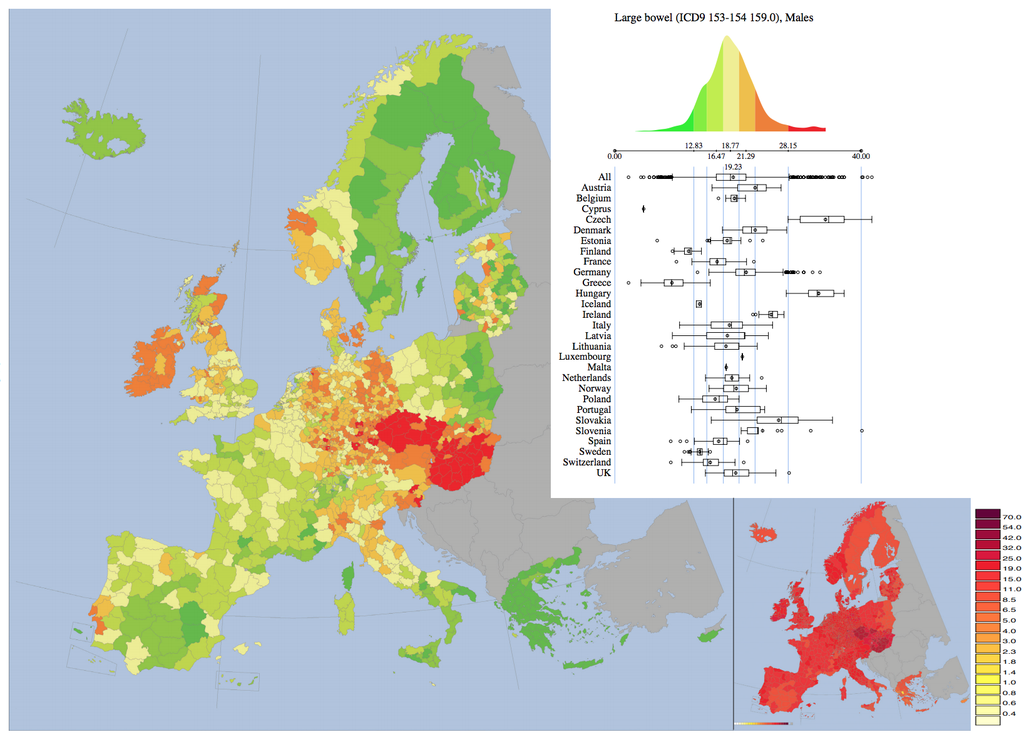

Example of standard deviation visualised in cancer mapping

[output not shown]

## Cartograms

A cartogram alters the map base with the intention of improving the presentation of the statistic of interest. For a single variable of interest, each map area is changed to emphasise the distribution by representing the corresponding value, in comparison to the value of the other areas (Dougenik, Chrisman, and Niemeyer 1985).

Choropleths may be considered true topological maps, however, if the land mass displayed covers enough of the globe, there must be a transformation or distortion to display the land in 2D. The amount of distortion is related to the distance covered by the landmass displayed Tobler (1963). World map projections reflect the frequent perspectives used to view the earth. Choropleth maps will always be distorted if they cover enough of the globe, just as photographs of the globe from space. Choropleth creation requires choosing a map projection that shows a favourable distortion of the geography for presenting the set of spatial information. Diagrams that do not specify a projection can be considered to have some unknown projection.

If the statistic presented on the map base relies on physical distance and is influenced by the topology there is no transformation needed beyond choosing a projection. The purposeful distortion of the map space is beneficial when a uniform density of the map base is desired. When a map base is transformed according to population density, population becomes a uniformly distributed background for the statistic presented (Berry, Morrill, and Tobler, n.d.).

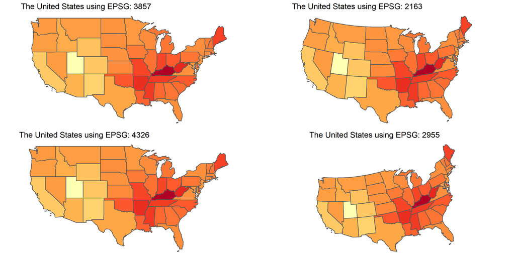

“Choropleth maps of the United States of America using four coordinate reference systems.”

If the statistic presented on the map base relies on physical distance and is influenced by the topology there is no transformation needed beyond choosing a projection. The purposeful distortion of the map space is beneficial when a uniform density of the map base is desired, Dorling (2011) suggests ‘population distribution is often extremely uneven in former British colonies’, this makes the distortion necessary. When a map base is transformed according to population density, population becomes a uniformly distributed background for the statistic presented (Berry, Morrill, and Tobler, n.d.). Using choropleth maps for population characteristics requires graphic distortions when the population concerned varies greatly in density (Griffin 1980). When implementing a distortion of the geographical shape according to population, an area cartogram (Olson 1976), population-by-area cartograms (Levison and Haddon Jr 1965), or iso-demographic map is the result.

Cartograms provide an alternative visualisation method for statistical and geographical information. The key difference between a choropleth and a cartogram is the desirable augmentation of the size, shape or distance of geographical areas (Dorling 2011). Cartograms may be seen as an extension of map transformations and projections. The favourable distortion is proportional to a value other other than actual earth size area (Olson 1976). A disadvantage of the conventional map is that sparsely populated rural areas may be emphasized, whereas the areas representing cities are very small, making interpretation of spatial patterns very difficult. The distortion of a cartogram prevents the density obscuring the spatial patterns (Levison and Haddon Jr 1965). The spatial transformation of map regions relative to the data emphasises the data distribution instead of land size (Kocmoud and House 1998). When visualising population statistics Dorling (2011) considers this equitable representation design ‘more socially just’, or honest (Dent 1972), giving due attention to all members of the population and reducing the visual impact of large areas with small populations (Walter 2001). Griffin (1980) suggest that spatial socio-economic data is best presented on a cartogram for urban areas. Howe (1989) agrees that ‘cancer occurs in people, not in geographical areas’ and the map bases of population reflect this and avoid allocating ‘undue prominence’ to rural areas. Jahan et al. (2018) encourage the use of cartograms to highlight small areas and uncover local-level inequalities.

The creation of cartograms was largely in the hands of professional cartographers (Kraak 2017). Dorling (2011) discusses early approaches including John Hunter and Jonathan Young (1968) and Durham’s wooden tile method, Skoda and Robertson’s (1972) steel ball bearing approach and Tobler’s (1973) computer programs. Howe (1989) discusses the impact of electronic computer-assisted techniques. Geographical information systems allowed map users, and researchers to implement their own cartograms, but these systems are utilised depending on ‘the effectiveness, efficiency, and satisfaction of the map products (Nielsen 1994)’(Kraak 2017).

There have been many algorithms presented, Nusrat and Kobourov (2016) provided a framework to investigate implementations and the “statistical accuracy, geographical accuracy, and topological accuracy”.

There are many alternatives to consider, the intended audience of the map, and its purpose are key points in cartogram use and creation. Dorling (2011) reiterates: ‘There is no “best” cartogram or method of creating cartograms just as there is no “best” map’ (Monmonier and Schnell, 1988).

### Contiguous

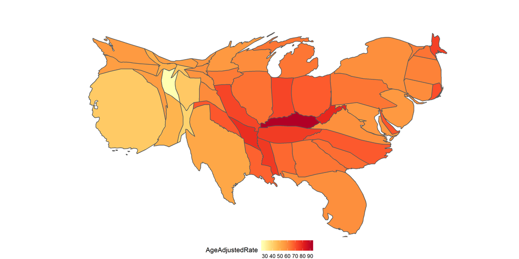

“A contiguous cartogram of the Unites States of America”

An intentional goal when creating the 1966 Census population cartogram for Canada was to maintain contiguity, while attempting to keep the actual shape of places. The end result was a ‘very accurate isodemo-graphic map of Canada’. This intentional design goal coincided with the rising interest in urban geography.

### Non-Contiguous

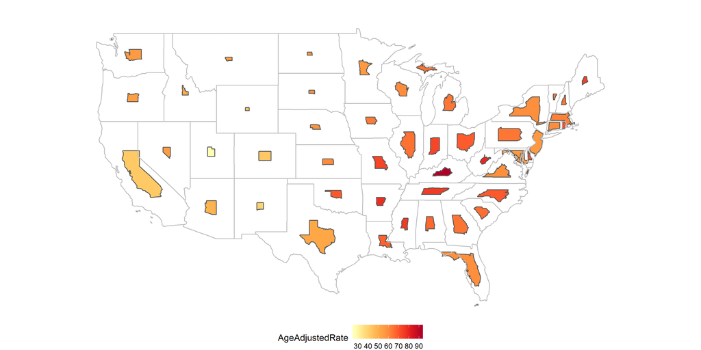

“A Non - contiguous cartogram of the Unites States of America”

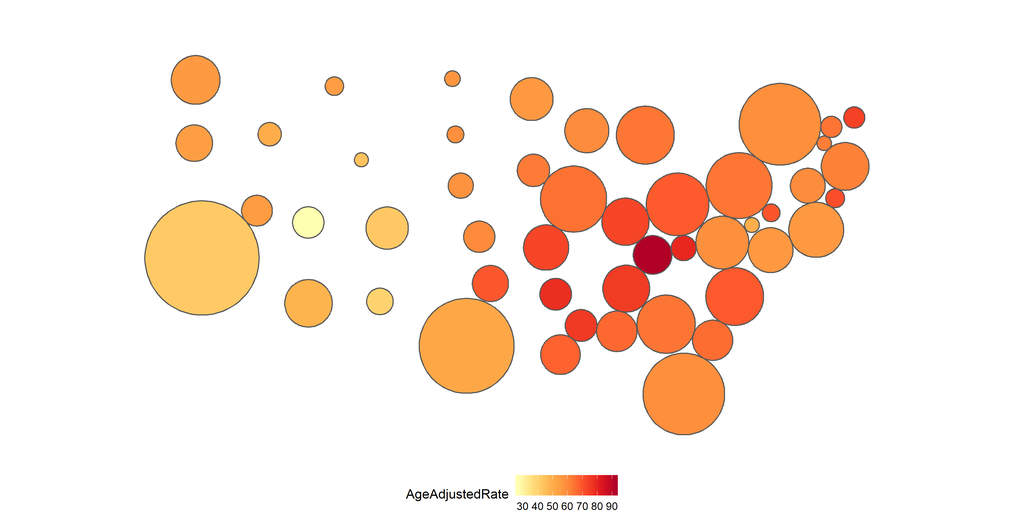

“A dorling cartogram of the Unites States of America”

Dorling (2011) puts forward a simple question:

> “If, for instance, it is desirable that areas on a map have boundaries which are as simple as possible, why not draw the areas as simple shapes in the first place?”

He answers this with his implementation of maps created with ‘the simplest of all shapes’. While contiguous cartograms may be a ‘more sophisticated’ method, they produce ‘very complex shapes’. Circular cartograms use the same shape for every region represented, and size them according to the statistic represented or the population for a base map. To produce a compelling map, a gravity model is applied to avoid overlaps, and keep spatial relationships with neighbouring areas over many iterations. This implementation can work for up to ‘one hundred thousand’ areas.

‘Given the increasingly uneven population distribution of the United States and the growing social divides between the populations of neighbourhoods living at different densities, the need for cartograms like this is greater now than ever.’

Used in displays of the UK by Howe in 1986 cited by Howe (1989)

Tobler’s method and the many implementations that ‘elaborated’ on it are derived from ‘numerical approximations to a pair of equations’(Dorling 2011). They all operate through incremental adjustments, and can produce wildly different outcomes from small changes in the inputs.

Tobler (2004) Value-Area Cartograms. In these cartograms a region,country, or continent is subdivided into small regions, each of which is represented by a rectangle. This rectangle is proportionate in area to the value which it represents in certain statistical distributions. The regions are grouped in approximately the same positions as they are on the map.

Cano et al. (2015) define the term ‘mosaic cartograms’. Compare amount of tiles to contrast population of regions. ‘Cartograms show a data value per input region by scaling each region such that its area is proportional to its data value. Mosaic cartograms show data in multiples of tiles, hence the input data must consist of, or be cast into, small integer units.’

# A critique of mapping methods

> “designing a map tailored to precise goals [is] easier than forcing a single map to accommodate diverse objectives” Bell et al. (2006)

Waldo Tobler (2012) explores many graphical techniques, and suggests there are particular methods for particular purposes. To choose an approporiate map display, the map creator must consider the intended user, and message the map will communicate. It is the objectives of the investigator that will drive the choice of representation (Bell et al. 2006).

There are two keys presented by Moore and Carpenter (1999) to drive the choice of display: - the properties of the visualisation, and - the ease or accuracy of information extraction for map users

# Animation and Interactivity

Recent developments in technology allowed interactive web atlases.

> “Where control of the message is important, static maps will continue to be the most effective, although good tables, graphs, and explanatory text are still needed in order to ensure that different people will see the same thing in the maps” Bell et al. (2006)

The intention of interactivity and animation is to allow users to answer their own questions.

# References

Wickham (2017) for data analysis, Bivand, Nowosad, and Lovelace (2019) and Pebesma (2018) to implement plotting of spatial data. Kobakian and Cook (2019) to create hexagon tesselation. Arnold (2019) to enhance plot displays. Jeworutzki (2018) for contiguous and non-contiguous cartogram displays.

Arnold, Jeffrey B. 2019. *Ggthemes: Extra Themes, Scales and Geoms for ’Ggplot2’*. https://CRAN.R-project.org/package=ggthemes.

Bell, B Sue, Richard E Hoskins, Linda Williams Pickle, and Daniel Wartenberg. 2006. “Current Practices in Spatial Analysis of Cancer Data: Mapping Health Statistics to Inform Policymakers and the Public.” *International Journal of Health Geographics* 5: 49. https://doi.org/10.1186/1476-072X-5-49.

Berry, Brian J. L., Richard L. Morrill, and Waldo R. Tobler. n.d. “GEOGRAPHIC Ordering of Information: NEW Opportunities” 16 (4): 39–44. https://doi.org/10.1111/j.0033-0124.1964.039_q.x.

Bivand, Roger, Jakub Nowosad, and Robin Lovelace. 2019. *SpData: Datasets for Spatial Analysis*. https://CRAN.R-project.org/package=spData.

Brewster, Mark B., and S. V. Subramanian. 2010. “Cartographic Insights into the Burden of Mortality in the United Kingdom: A Review of ‘The Grim Reaper’s Road Map’.” Journal Article. *International Journal of Epidemiology* 39 (4): 1120–2. https://doi.org/10.1093/ije/dyp395.

Cano, R. G., K. Buchin, T. Castermans, A. Pieterse, W. Sonke, and B. Speckmann. 2015. “Mosaic Drawings and Cartograms.” *Computer Graphics Forum* 34 (3): 361–70.

Dent, Borden D. 1972. “A Note on the Importance of Shape in Cartogram Communication.” *Journal of Geography* 71 (7): 393–401. https://doi.org/10.1080/00221347208981697.

d’Onofrio, Alberto, Chiara Mazzetta, Chris Robertson, Michel Smans, Peter Boyle, and Mathieu Boniol. 2016. “Maps and Atlases of Cancer Mortality: A Review of a Useful Tool to Trigger New Questions.” Journal Article. *Ecancermedicalscience* 10: 670–70. https://doi.org/10.3332/ecancer.2016.670.

Dorling, Daniel. 2011. “Area Cartograms: Their Use and Creation.” In *Concepts and Techniques in Modern Geography (CATMOG)*, 59:252–60. https://doi.org/10.1002/9780470979587.ch33.

———. 2012. *The Visualisation of Spatial Social Structure*. John Wiley & Sons Ltd.

Dougenik, James A., Nicholas R. Chrisman, and Duane R. Niemeyer. 1985. “AN Algorithm to Construct Continuous Area Cartograms.” *The Professional Geographer* 37 (1): 75–81. https://doi.org/10.1111/j.0033-0124.1985.00075.x.

Exeter, Daniel J. 2017. “Spatial Epidemiology.” Journal Article, 1–4. https://doi.org/10.1002/9781118786352.wbieg0283.

Griffin, T.L.C. 1980. “Cartographic Transformation of the Thematic Map Base.” *Cartography* 11 (3): 163–74. https://doi.org/10.1080/00690805.1980.10438102.

Howe, G. M. 1989. “Historical Evolution of Disease Mapping in General and Specifically of Cancer Mapping.” In *Cancer Mapping*, edited by Peter Boyle, Calum S. Muir, and Ekkehard Grundmann, 1–21. Berlin, Heidelberg: Springer Berlin Heidelberg.

Jahan, Farzana, Earl Duncan, Susanna Cramb, Peter Baade, and Kerrie Mengersen. 2018. “Making More of Spatial Maps: A Bayesian Meta-Analysis Approach.” In.

Jeworutzki, Sebastian. 2018. *Cartogram: Create Cartograms with R*. https://CRAN.R-project.org/package=cartogram.

Keim, D.A, S.C North, C Panse, and J Schneidewind. 2002. “Efficient Cartogram Generation: A Comparison.” In *IEEE Symposium on Information Visualization, 2002. INFOVIS 2002*, 2002-:33–36. IEEE.

Kobakian, Stephanie, and Dianne Cook. 2019. *Sugarbag: Create Tessellated Hexagon Maps*. https://CRAN.R-project.org/package=sugarbag.

Kocmoud, Christopher J., and Donald H. House. 1998. “A Constraint-Based Approach to Constructing Continuous Cartograms.” In.

Kraak, M. J. 2017. “Cartographic Design.” In *The International Encyclopedia of Geography : People, the Earth, Environment, and Technology*, edited by D. Richardson, 1–16. United States: Wiley.

Levison, M. E., and W. Haddon Jr. 1965. “THE Area Adjusted Map. AN Epidemiologic Device.” Journal Article. *Public Health Reports* 80: 55–59.

Min Ouyang, and P. Revesz. 2000. “Algorithms for Cartogram Animation.” In *Proceedings 2000 International Database Engineering and Applications Symposium (Cat. No.PR00789)*, 231–35. https://doi.org/10.1109/IDEAS.2000.880581.

Moore, Dale A., and Tim E. Carpenter. 1999. “Spatial Analytical Methods and Geographic Information Systems: Use in Health Research and Epidemiology.” *Epidemiologic Reviews* 21 (2): 143–61. https://doi.org/10.1093/oxfordjournals.epirev.a017993.

Nusrat, Sabrina, and Stephen G. Kobourov. 2016. “The State of the Art in Cartograms.” *CoRR* abs/1605.08485. http://arxiv.org/abs/1605.08485.

Olson, Judy M. 1976. “NONCONTIGUOUS Area Cartograms.” *The Professional Geographer* 28 (4): 371–80. https://doi.org/10.1111/j.0033-0124.1976.00371.x.

Pebesma, Edzer. 2018. “Simple Features for R: Standardized Support for Spatial Vector Data.” *The R Journal* 10 (1): 439–46. https://doi.org/10.32614/RJ-2018-009.

Tobler, Waldo. 1963. “Geographic Area and Map Projections,” January, 59–78. https://www.jstor.org/stable/212809.

———. 2004. “Thirty Five Years of Computer Cartograms.” *Annals of the Association of American Geographers* 94 (1): 58–73.

Tufte, Edward R. 1990. *Envisioning Information*. Graphics Press.

Walter, S. D. 2001. *Disease Mapping: A Historical Perspective*. Book. Oxford University Press: Oxford.

Wickham, Hadley. 2017. *Tidyverse: Easily Install and Load the ’Tidyverse’*. https://CRAN.R-project.org/package=tidyverse.